# 2864assignment4

Yufei xia

2019/3/28

# question1

```r
#(a)
set.seed(19908)
x = runif(10000)
y = 3*(-log(-log(x)))+1.5
mean(y)
```

```
## [1] 3.224732
```

```r
sd(y)
```

```
## [1] 3.843677
```

```r
#(b)
#the theortical mean and sd is
1.5+3.0*0.5772
```

```
## [1] 3.2316
```

```r
#the theoritical sd is
3.0*pi/sqrt(6)
```

```
## [1] 3.847649
```

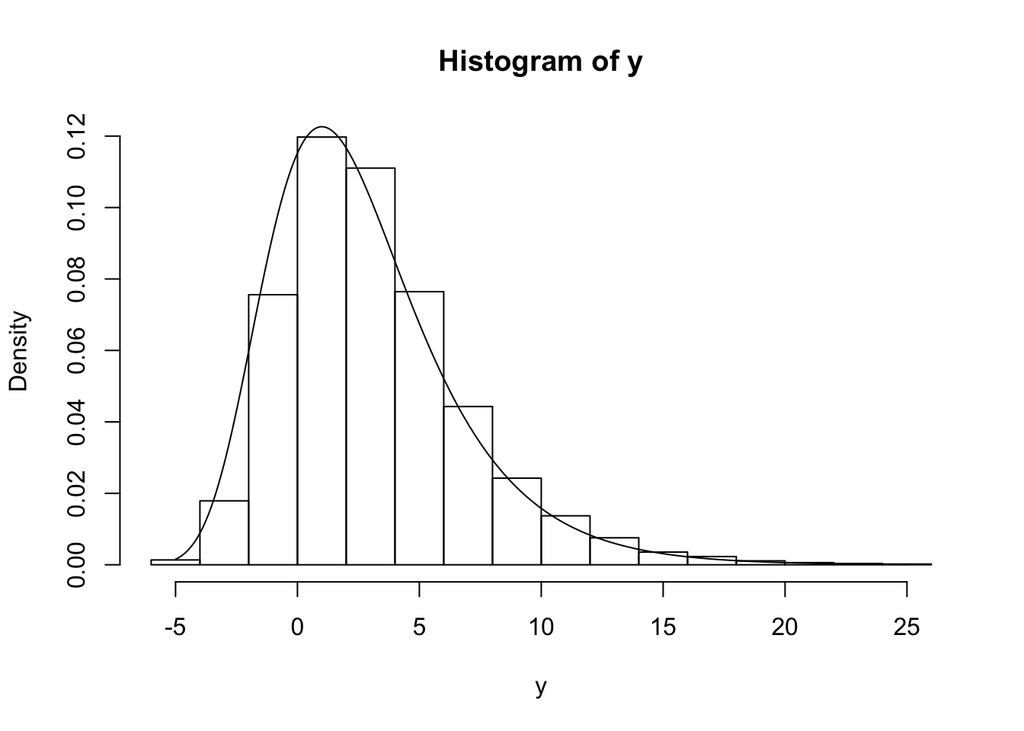

```r
#(C)
hist(y,probability = T)
x.seq = seq(-5,25,.05)
k = (x.seq - 1)/3
y.seq = 1/3*exp(-k -exp(-k))
lines(x.seq , y.seq)
```

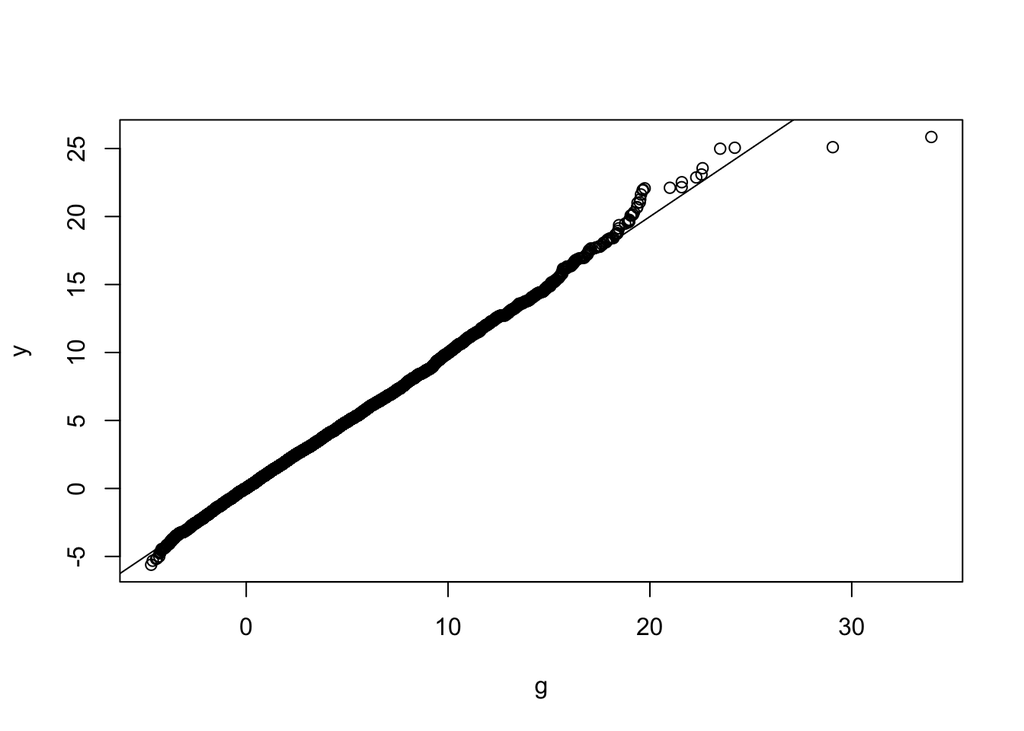

```r
#(d)
g= rgumbel(10000,1.5,3)
qqplot(g,y)
abline(0,1)
```

```r
#the result show that the inverse function generated  number basiclly track with the generated number with rgumbel funtion
```

1. the mean and sd of the numbers in Y is 3.224732 and 3.843677
2. the true mean and sd is 3.2316 and 3.847649,which are quite colse to inverse method generated mean and sd. (c)from the plot, we know that the theoritical pdf plot track exactly as the bootstrap generated solutions (d)the result show that the inverse function generated number basiclly has the same distribution as rgumbel function genereted number except for some outliers.

# question2

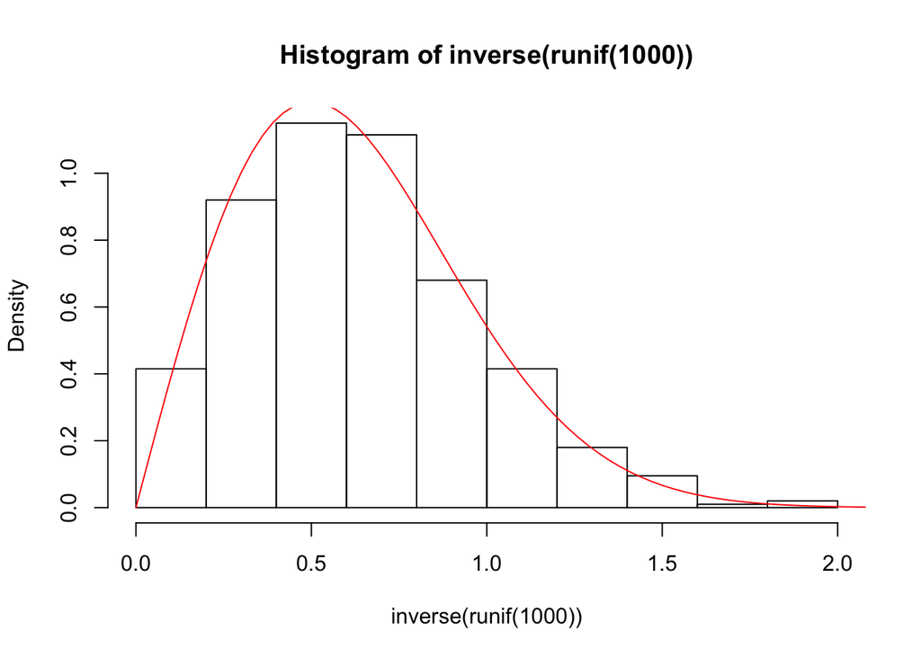

```r
#Question 2
#a)
den=function(x){
  f=x/0.25*exp(-x^2/0.5)
  return(f)
}
inverse=function(x,a=0.5){
  f=a*sqrt(-2*log(1-x))
  return(f)
}

A=inverse(runif(20))
hist(inverse(runif(1000)),probability=TRUE)
curve(den(x),from=0,to=3,col=2,add=TRUE)
```

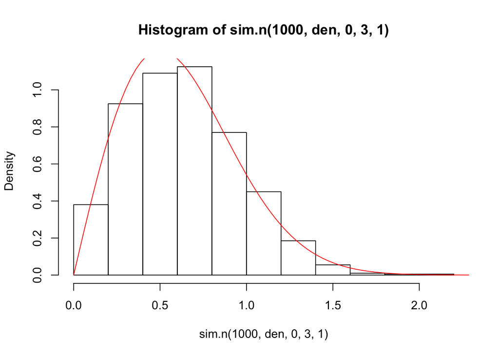

```r
#from the plot ,we can see that the theoritical pdf track excatly as inverse method generated number
#(b)
sim.n=function(n,fun,a,b,M){
  x=double(n)
  init<-0
  repeat {
    t=runif(n-init,a,b)
    u=runif(n-init)
    accept=(M*u<=fun(t))
    m=sum(accept)
    if(m>0)
      x[(init+1):(m+init)]=t[accept]
    if((m+init) ==n)
      break
    init=init+m
  }
  x
}

x=sim.n(20,den,0,3,1)
hist(sim.n(1000,den,0,3,1),probability=TRUE)
curve(den(x),from=0,to=3,col=2,add=TRUE)
```

```r
#from the plot ,we can see that the theoritical pdf track excatly as rejection method generated number

#c)
system.time(inverse(runif(100000)))
```

```
##    user  system elapsed
##   0.004   0.000   0.004
```

```r
system.time(sim.n(100000,den,0,3,1))
```

```
##    user  system elapsed
##   0.027   0.003   0.030
```

```r
#from compare the system time of inverse method and rejection method in term of generating 100000 number. we know that inverse method is much faster than rejection method.
```

(a)from the plot ,we can see that the theoritical pdf track excatly as inverse method generated number. (b)from the plot ,we can see that the theoritical pdf track excatly as rejection method generated number. (c)from compare the system time of inverse method and rejection method in term of generating 100000 number. we know that inverse method is much faster than rejection method.